# Zone Assignment

Bryce McManus

2022-02-17

## Intro

This document shows how observations are assigned in FishSET and compares zone assignments with those found in the most recent version of the scallop data (provided Oct/Nov 2021). It then illustrates certain factors that can affect zone assignment: polygon boundary types, spherical v. planar geometry, and spatial joins.

## Library

```r
# Set Path
here::i_am("scallop_zone_assignment.Rmd")
```

```
## here() starts at /net/home2/mlee/Effort-Displacement---Scallop
```

```r
# Install Packages if necessary and Load Libraries
PKG <- c("here","leaflet", "tidyverse", "sf")
for (p in PKG) {
  if(!require(p,character.only = TRUE)) {
    install.packages(p)
    require(p,character.only = TRUE)}
}
# Set data vintage
vintage_string<-"2022_02_16"
```

## Data

This is the data from the most recent Kiteworks folder that was shared with the FishSET team in Oct/Nov of last year.

```r
# load in Oct 18 data.
scallop_10_18 <- read_csv(here("data","main","cost_join_10_18.csv"))
```

```
## * `` -> ...1
```

```r
# load in final product
final_product_savename<-paste0("final_product_lease",vintage_string,".Rds")
final_product_lease<-readRDS(here("data","main",final_product_savename))

# overwrite
#scallop_10_18<-final_product_lease

# Load in 10 minute squares
tenMinSqr_new <-
  here("data",
       "external",
       "shapefiles",
       "Ten Minute Squares Cut North and Greater Atlantic") %>%
  st_read() %>%
  st_zm() # remove Z/M dimensions from feature
```

Check for duplicate trip IDs.

```r
nrow(scallop_10_18)
```

```
## [1] 34737
```

```r
scallop_10_18 %>%
  distinct(TRIPID) %>%
  nrow()
```

```
## [1] 34737
```

## Zone assignment

This is the approach we take in FishSET to assign observations to zones.

```r
# create sf version of data, convert to WGS84
# crs <- st_crs(tenMinSqr_new) # using crs from ten minute squares didn't change results
crs <- 4326

scallop_sf <-
  st_as_sf(x = scallop_10_18, coords = c("DDLON", "DDLAT"),
           crs = crs)

# convert Squares to WGS84
tenMinSqr_new <- st_transform(tenMinSqr_new, crs = st_crs(scallop_sf))

# same results as st_within
inter <- sf::st_intersects(scallop_sf, tenMinSqr_new)

inter_save <- inter

 if (any(lengths(inter) > 1)) { # if more than one zone intersects, assign to closest zone

  dub <- which(lengths(inter) > 1)
  inter[dub] <- st_nearest_feature(scallop_sf[dub,], tenMinSqr_new)
 }

# Add ZoneID column to data
pts <- as.data.frame(as.numeric(inter))
colnames(pts) <- "col.id"
pts$ID <- tenMinSqr_new$MN10SQID[pts$col.id]
scallop_sf$ZoneID <- pts$ID
```

```r
table(lengths(inter_save))
```

```
##
##     1
## 34737
```

After reassigning zones with 2+ intersections to the nearest zone.

```r
table(lengths(inter))
```

```
##
##     1
## 34737
```

## FishSET v. NE zone assignment

```r
scallop_sf <- scallop_sf %>%
  mutate(fs_ne_match = ZoneID == MN10SQID)

# add ZoneID and match col to scallop_10_18
scallop_10_18 <-
  scallop_sf %>%
  st_set_geometry(NULL) %>%
  select(ZoneID, fs_ne_match) %>%
  bind_cols(scallop_10_18, .)

# summary table of matching IDs
scallop_sf %>%
  st_set_geometry(NULL) %>%
  summarize(n_obs = n(),
            id_match = sum(fs_ne_match, na.rm = TRUE),
            id_no_match = sum(!fs_ne_match, na.rm = TRUE),
            perc_match = id_match/n() * 100,
            perc_no_match = 100 - perc_match)
```

| n_obs | id_match | id_no_match | perc_match | perc_no_match |
| --- | --- | --- | --- | --- |
| 34737 | 33523 | 1214 | 96.50517 | 3.494833 |

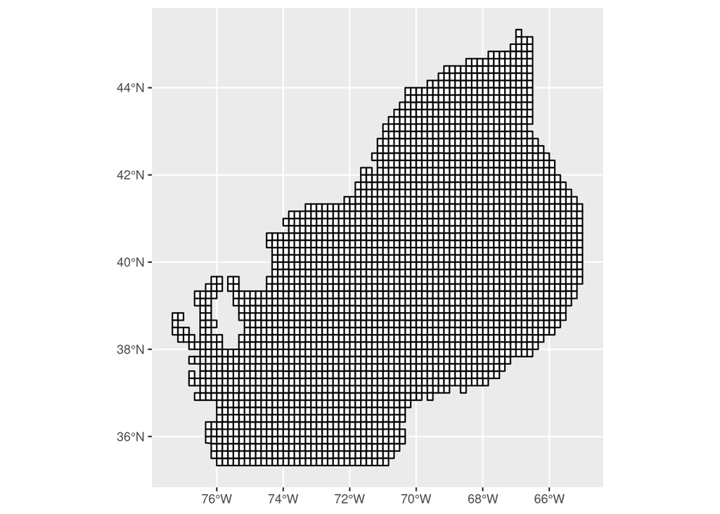

```r
s_bbox <- st_bbox(filter(scallop_sf, is.na(ZoneID)))

ggplot() +
  geom_sf(data = tenMinSqr_new, fill = "white", color = "black") +
  geom_sf(data = filter(scallop_sf, is.na(ZoneID)),color = "red") +
  coord_sf(xlim = c(s_bbox[1], s_bbox[3]), ylim = c(s_bbox[2], s_bbox[4]))
```

The difference in zone assignment appears only to occur on zone boundaries and intersections.

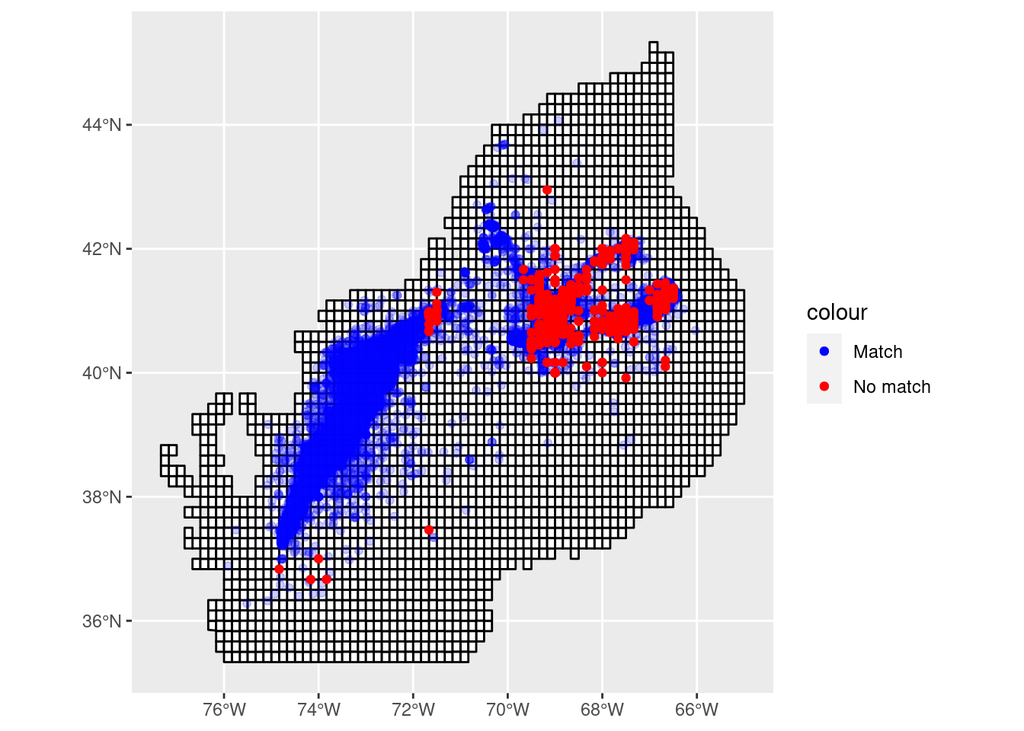

```r
ggplot() +
  geom_sf(data = tenMinSqr_new, fill = "white", color = "black") +
  geom_sf(data = filter(scallop_sf, fs_ne_match),
          aes(color = "Match"),
          alpha = .2,
          show.legend = "point") +
  geom_sf(data = filter(scallop_sf, !fs_ne_match),
          aes(color = "No match"),
          show.legend = "point") +
  coord_sf(xlim = c(s_bbox[1], s_bbox[3]), ylim = c(s_bbox[2], s_bbox[4])) +
 scale_color_manual(values = c("Match" = "blue", "No match" = "red"))
```

This leaflet plot shows the first 20 non-matching zone assignments. Each point has a label showing the zone assigned by FishSET and by NE.

```r
# marker labels for leaflet plots
scallop_10_18 <-
  scallop_10_18 %>%
  mutate(ZoneID_lab = paste0("FS: ", ZoneID, "<br/>"),
         MN10SQID_lab = paste0("NE: ", MN10SQID, "<br/>")) %>%
  unite("unite_lab", ZoneID_lab, MN10SQID_lab, sep = " ") %>%
  mutate(unite_lab = paste0(unite_lab, "lon: ", DDLON, "<br/>lat: ", DDLAT))

fs_no_match <- scallop_10_18 %>%
  filter(fs_ne_match == FALSE) %>%
  head(20) %>%
  pull(ZoneID)

ne_no_match <- scallop_10_18 %>%
  filter(fs_ne_match == FALSE) %>%
  head(20) %>%
  pull(MN10SQID)

leaflet() %>%
  addTiles() %>%
  addPolygons(data = filter(tenMinSqr_new, MN10SQID %in% c(fs_no_match, ne_no_match)),
              fillColor = "white",
              fillOpacity = 0.5,
              color = "black",
              stroke = TRUE,
              weight = 1,
              labelOptions = labelOptions(noHide = TRUE),
              layerId = ~MN10SQID,
              label = ~MN10SQID) %>%
  addMarkers(data = head(filter(scallop_10_18, fs_ne_match == FALSE), 20),
             lng = ~DDLON, lat = ~DDLAT,
             label = ~lapply(unite_lab, htmltools::HTML))
```

[interactive chart not shown]

Similar to the plot above, but comparing the unassigned points in `ZoneID` with `MN10SQID`.

```r
if (sum(is.na(scallop_10_18$ZoneID)) > 0) {

  fs_na <- scallop_10_18 %>%
  filter(is.na(ZoneID)) %>%
  pull(MN10SQID)

leaflet() %>%
  addTiles() %>%
  addPolygons(data = filter(tenMinSqr_new, MN10SQID %in% fs_na),
              fillColor = "white",
              fillOpacity = 0.5,
              color = "black",
              stroke = TRUE,
              weight = 1,
              labelOptions = labelOptions(noHide = TRUE),
              layerId = ~MN10SQID,
              label = ~MN10SQID) %>%
  addMarkers(data = filter(scallop_10_18, is.na(ZoneID)),
             lng = ~DDLON, lat = ~DDLAT,
             label = ~lapply(unite_lab, htmltools::HTML))
}
```

## Factors that may affect point assignment

### Polygon boundary types

Point assignment can vary depending on whether polygon boundaries are treated as “closed”, “open”, or “semi-open”.

```r
inter_closed <- lengths(st_intersects(scallop_sf, tenMinSqr_new, model = "closed"))
inter_open <- lengths(st_intersects(scallop_sf, tenMinSqr_new, model = "open"))
inter_semi <- lengths(st_intersects(scallop_sf, tenMinSqr_new, model = "semi-open"))

bound_type <- tibble(Closed = inter_closed, Open = inter_open, Semi = inter_semi)

pivot_longer(bound_type, cols = c("Closed", "Open", "Semi"),
             names_to = "boundary_type", values_to = "Zones_assigned") %>%
  group_by(boundary_type) %>%
  count(Zones_assigned)
```

| boundary_type | Zones_assigned | n |
| --- | --- | --- |
| Closed | 1 | 34737 |
| Open | 1 | 34737 |
| Semi | 1 | 34737 |

### sf version < 1.0

Sf 1.0+ uses spherical geometry (S2) on coordinates, sf < 1.0 uses planar geometry (R2).

```r
# test difference in S2 and R2 methods
sf_use_s2(FALSE)
```

```
## Spherical geometry (s2) switched off
```

```r
inter_closed_r2 <- lengths(st_intersects(scallop_sf, tenMinSqr_new, model = "closed"))
```

```
## although coordinates are longitude/latitude, st_intersects assumes that they are planar
## although coordinates are longitude/latitude, st_intersects assumes that they are planar
```

```r
inter_open_r2 <- lengths(st_intersects(scallop_sf, tenMinSqr_new, model = "open"))
```

```
## although coordinates are longitude/latitude, st_intersects assumes that they are planar
## although coordinates are longitude/latitude, st_intersects assumes that they are planar
```

```r
inter_semi_r2 <- lengths(st_intersects(scallop_sf, tenMinSqr_new, model = "semi-open"))
```

```
## although coordinates are longitude/latitude, st_intersects assumes that they are planar
## although coordinates are longitude/latitude, st_intersects assumes that they are planar
```

```r
sf_use_s2(TRUE)
```

```
## Spherical geometry (s2) switched on
```

```r
bound_type_r2 <- tibble(Closed = inter_closed_r2,
                        Open = inter_open_r2,
                        Semi = inter_semi_r2)

pivot_longer(bound_type_r2, cols = c("Closed", "Open", "Semi"),
             names_to = "boundary_type", values_to = "Zones_assigned") %>%
  group_by(boundary_type) %>%
  count(Zones_assigned)
```

| boundary_type | Zones_assigned | n |
| --- | --- | --- |
| Closed | 1 | 34737 |
| Open | 1 | 34737 |
| Semi | 1 | 34737 |

### Spatial join

Spatial joins will add additional rows if a point intersects more than one zone. If an inner join is used (`left = FALSE`), points that don’t intersect zones are dropped.

```r
scallop_sf_join <- st_join(scallop_sf,
                           tenMinSqr_new["MN10SQID"],
                           suffix = c(".x", ".y"),
                           left = TRUE)

scallop_sf_join <-
  scallop_sf_join %>%
  mutate(fs_join_match = ZoneID == MN10SQID.y,
         ne_join_match = MN10SQID.x == MN10SQID.y)

scallop_sf_join %>%
  st_set_geometry(NULL) %>%
  summarize(n_obs = n(),
    fs_join_match = sum(fs_join_match, na.rm = TRUE),
    ne_join_match = sum(ne_join_match, na.rm = TRUE),
    fs_ne_match = sum(fs_ne_match, na.rm = TRUE))
```

| n_obs | fs_join_match | ne_join_match | fs_ne_match |
| --- | --- | --- | --- |
| 34737 | 34737 | 33523 | 33523 |

```r
nrow(scallop_sf_join)
```

```
## [1] 34737
```

```r
scallop_sf_join %>%
  st_set_geometry(NULL) %>%
  distinct(TRIPID) %>%
  nrow()
```

```
## [1] 34737
```

Table of matching zones by FishSET, NE, and spatial join approaches.

```r
scallop_sf_join %>%
    st_set_geometry(NULL) %>%
    count(fs_ne_match, fs_join_match, ne_join_match)
```

| fs_ne_match | fs_join_match | ne_join_match | n |
| --- | --- | --- | --- |
| FALSE | TRUE | FALSE | 1214 |
| TRUE | TRUE | TRUE | 33523 |

```r
dup_trip_id <- scallop_10_18$TRIPID[lengths(inter_save) > 1]

scallop_sf_join <-
  scallop_sf_join %>%
  mutate(dup_zone = TRIPID %in% dup_trip_id)

scallop_sf_join %>%
  st_set_geometry(NULL) %>%
  filter(!fs_ne_match & !fs_join_match & !ne_join_match) %>%
  summarize(dup_zone = sum(dup_zone))
```

| dup_zone |
| --- |
| 0 |